# Futuro e a CompuFácil

## /sobre

Líder técnico na CompuFácil

Programador, professor

Maiores interesses: ciência e humanismo

Twitter: JeanCarloMachad

# Futuro

Para Saber o futuro precisamos acompanhar o passado e a tendência do presente

# Distópico

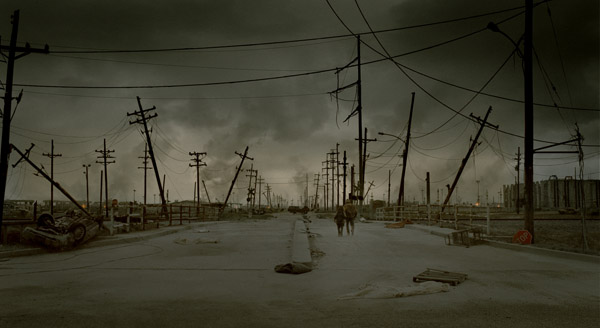

Distópico

# Utópico

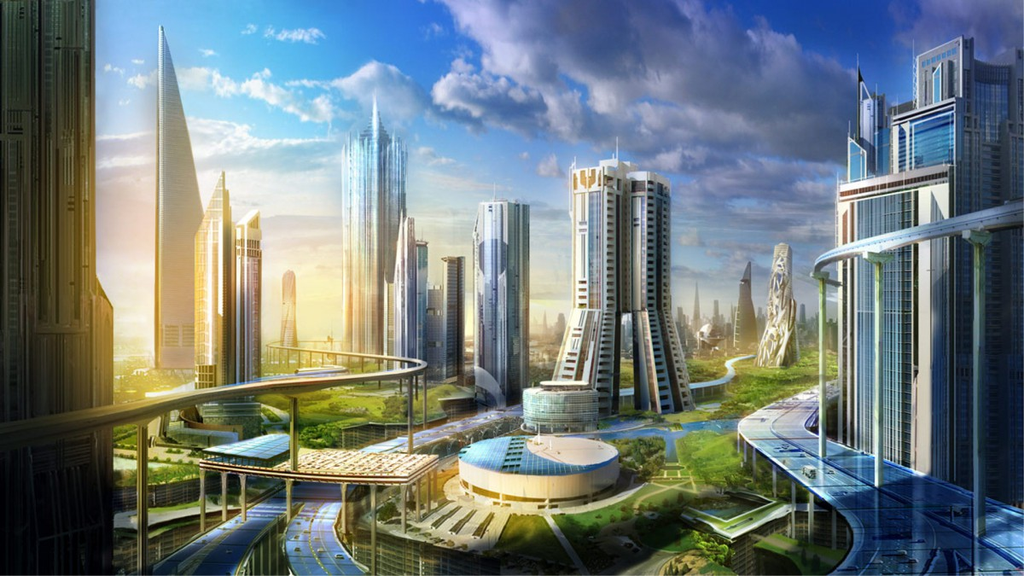

Utópico

Estamos no período mais próspero da história da humanidade

[figure not shown]

Extrema Pobreza

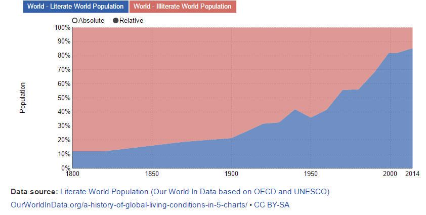

Educação básica

[figure not shown]

Mortalidade Infantil

# Sustentabilidade

### Sustentabilidade = eficiência

- infraestrutura compartilhada
- não se vende computadores, vende-se computação
- custo por demanda
- facilidade de automatização *serverless*

*Civilization advances by extending the number of important operations we can perform without thinking. ~ A. N. Whitehead*

# Nuvem

- dados centralizados
- Detectar erros antes dos próprios clientes
- Novas versões instantaneamente
- Acesso em qualquer lugar, qualquer dispositivo WEB

[figure not shown]

Nuvem meu filho

## Economias Compartilhadas

- A maior empresa de carros do mundo não tem carros
- A maior empresa de imóveis do mundo não possui imóveis
- A maior empresa de comércio eletrônico do mundo não tem estoque

~ Edson Yanaga

[figure not shown]

Uber + Telsa

### Blockchain

- Dinheiro online, descentralizado, global
- Novos modelos de negócios
- Novas formas de se pensar sobre gestão financeira
- Sistemas de votação

# Inteligência

## IOT

Em 2015 existiam 4.9 milhões de dispositivos conectados a internet

Em 2020 estimas-se 21 bilhões

[Amazon Go](https://www.youtube.com/watch?v=NrmMk1Myrxc)

## Big Data

- Dados centralizados permitem a mineração
- Descobrir o que vai acontecer
- Relacionamentos inesperados de dados
- Prevenção de problemas antes do acontecimento

## Inteligência Artificial

- Carros autônomos
- Detecção de humor
- Advogados/Juízes artificiais
- *AI will be the new UI*

## O que mais?

- Impressoras 3D
- Wearable's
- Drones
- Energia Solar
- Realidade virtual/aumentada
- Mapeamento Genético
- Customização genética (CRISPR)
- Assistentes pessoais (Alexa)

# Integrações

O mundo já tem muitas ideias genias

Para criar mais valor precisamos juntar elas

## API's

- Integrar outros sistemas
- Integrações a sistemas de terceiros
- Aplicativos próprios
- Aplicativos de terceiros
- Desenvolver novas funcionalidades

[figure not shown]

Integrações

## Nossos aplicativos

[figure not shown]

Checkout Maquininha

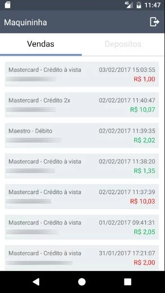

Relatórios Maquininha

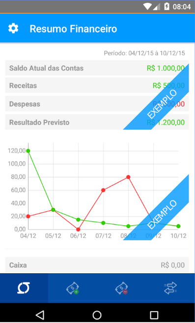

Controle financeiro

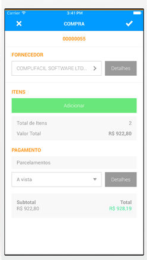

Controle estoque

[figure not shown]

NFC-e

## Ideias

- Nota fiscal de serviço para alguns municípios
- Whatsapp para receber novidades sobre vendas e vencimentos
- Criação automática de promoções baseada no vencimento de itens
- Mineração de melhores datas para entrar em contato com os clientes
- Checkout automático com RFID de produtos especiais
- Importador de transações bancárias fazendo crawling

## Ideias

- Pagamento direto sem necessidade de cartão com NFC ou Bitcoin
- Ferramenta para análise do perfil do cliente oferecer promoções
- Capturar informações de produtos como o RDstation para qualificar leads e direcionar para os nossos parceiros.
- Redução do estoque através da análise de comportamento dos clientes por sazonalidade
- Importador de histórico de estoque do Excel para a nossa API

## Resumindo

O futuro vai ser um lugar muito mais dinâmico e próspero

Quem quiser ter impacto vai ter que se adaptar

A tecnologia está muito mais democrática e nunca foi tão fácil revolucionar o mundo com ela

Integrar todas essas tecnologias maravilhosas vai permitir criarmos muito mais valor do que pensávamos ser possível

*The difference between a successful person and others is not a lack of strength, not a lack of knowledge, but rather a lack in will.*

~ Vince Lombardi Jr.

# Referências

1. [Saas como um ecossistema](https://www.slideshare.net/saasu/saas-as-an-ecosystem-presentation)
2. [The case of Adobe moving to the cloud](https://www.computerworld.com/article/3069711/software-as-a-service/transitioning-to-the-cloud-adobe-hits-it-out-of-the-park.html)
3. [10 anos de áudio em pt](http://revistagalileu.globo.com/Revista/Common/0,,EMI341118-17770,00-A+PESQUISA+POR+VOZ+SERA+ESSENCIAL+NA+INTERNET+DAS+COISAS.htmlk)
4. [Things Big Data Can Do, and 3 Things It Can’t Do](http://data-informed.com/4-things-big-data-can-do-and-3-things-it-cant-do/)
5. [Lawyers and IA](https://www.cnbc.com/2017/02/17/lawyers-could-be-replaced-by-artificial-intelligence.html)
6. [The future of the Internet of Things](https://us.norton.com/internetsecurity-iot-5-predictions-for-the-future-of-iot.html)
7. [Technology and the future](https://www.youtube.com/watch?v=k0mHMVETt_o)
8. [Our world in data](https://ourworldindata.org/)

# Obrigado

Contato: contato@jeancarlomachado.com.br